# Data-573 Assignment 2

Dhun Sheth

2024-03-12

## Question 1

### Part A

```r
data("HouseVotes84")
data <- HouseVotes84
new_level <- c("NoVote")
for (colname in names(data)[-1]) {
  if (is.factor(data[[colname]])) {
    current_levels <- levels(data[[colname]])
    all_levels <- unique(c(current_levels, new_level))
    data[[colname]] <- factor(data[[colname]], levels = all_levels)
    data[[colname]][is.na(data[[colname]])] <- new_level
  }
}
head(data)
```

```
##        Class     V1 V2 V3     V4     V5 V6 V7 V8 V9 V10    V11    V12 V13 V14
## 1 republican      n  y  n      y      y  y  n  n  n   y NoVote      y   y   y
## 2 republican      n  y  n      y      y  y  n  n  n   n      n      y   y   y
## 3   democrat NoVote  y  y NoVote      y  y  n  n  n   n      y      n   y   y
## 4   democrat      n  y  y      n NoVote  y  n  n  n   n      y      n   y   n
## 5   democrat      y  y  y      n      y  y  n  n  n   n      y NoVote   y   y
## 6   democrat      n  y  y      n      y  y  n  n  n   n      n      n   y   y
##   V15    V16
## 1   n      y
## 2   n NoVote
## 3   n      n
## 4   n      y
## 5   y      y
## 6   y      y
```

### Part B

```r
dist_matrix <- daisy(data[-1], metric = "gower")
```

### Part C

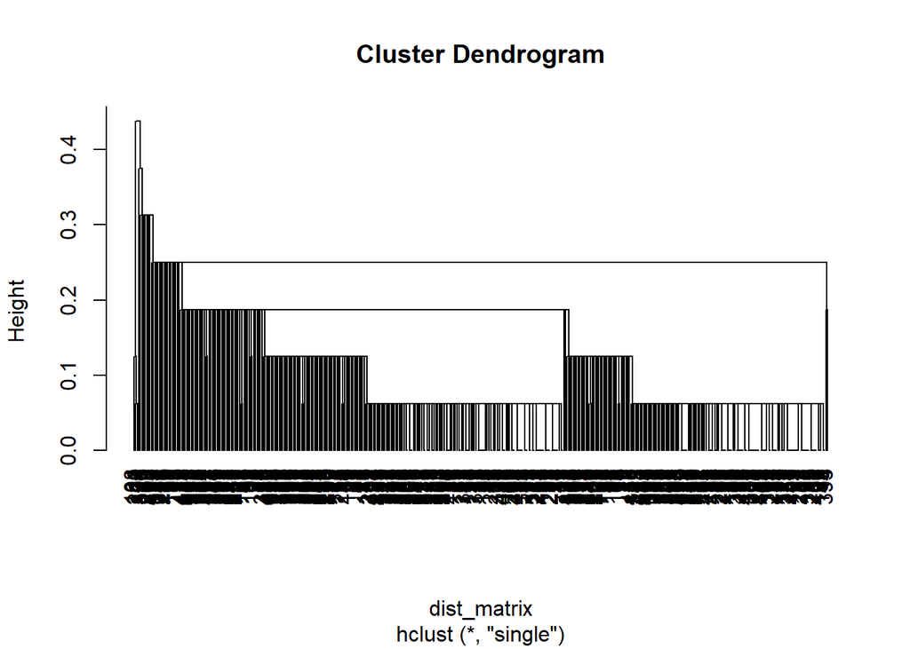

```r
hc_single <- hclust(dist_matrix, method = "single")
hc_complete <- hclust(dist_matrix, method = "complete")
hc_avg <- hclust(dist_matrix, method = "average")

plot(hc_single, hang = -1, labels = rownames(data))
```

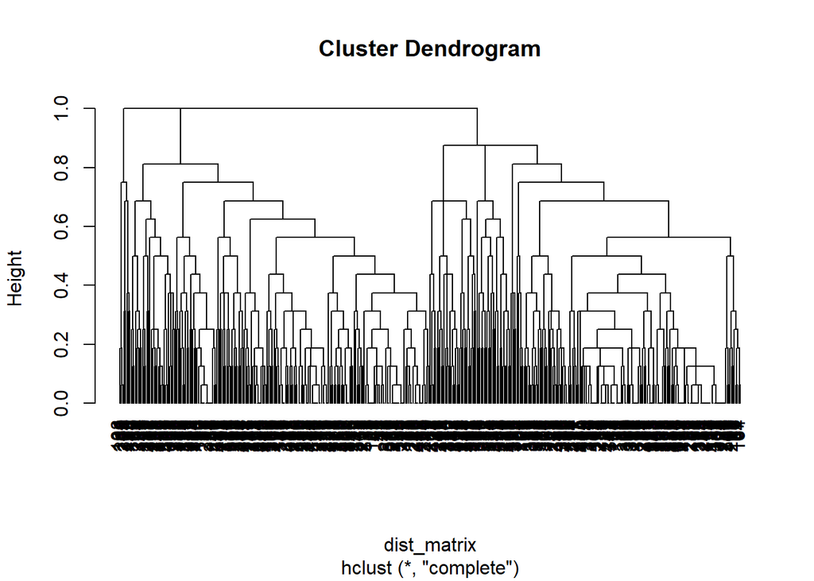

```r
plot(hc_complete, hang = -1, labels = rownames(data))
```

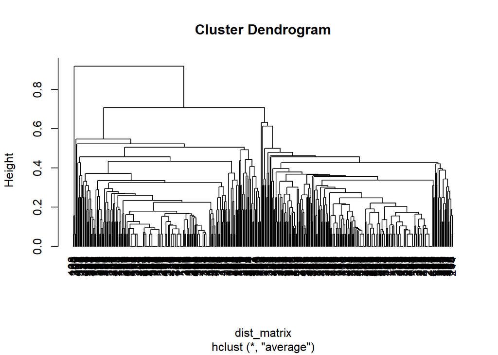

```r
plot(hc_avg, hang = -1, labels = rownames(data))
```

```r
clusters <- cutree(hc_complete, k=3)
conf_matrix <- table(data$Class, clusters)
print(conf_matrix)
```

```
##             clusters
##                1   2   3
##   democrat    58 204   5
##   republican 160   5   3
```

Complete linkage seems to provide the best results based on comparing the dendrograms. Complete linkage suggests there are 3 groups.

### Part D

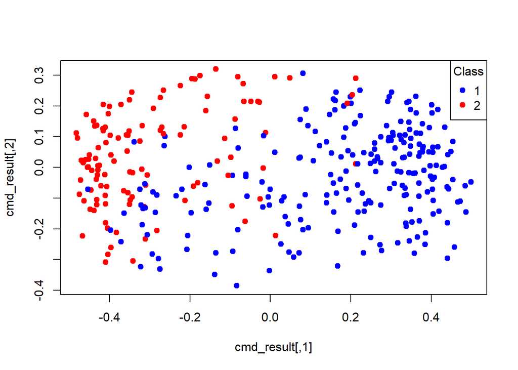

```r
cmd_result <- cmdscale(dist_matrix)
colors <- ifelse(data$Class == 'democrat', 'blue', 'red')
color_factor <- factor(colors, levels = c('blue', 'red'))

plot(cmd_result, col = colors, pch = 19)
legend("topright", legend = c('1','2'), col = levels(color_factor), pch = 19, title = "Class")
```

### Part E

```r
k_means <- kmeans(cmd_result, 2, nstart=25)
conf_matrix <- table(data$Class, k_means$cluster)
print(conf_matrix)
```

```
##
##                1   2
##   democrat   225  42
##   republican   9 159
```

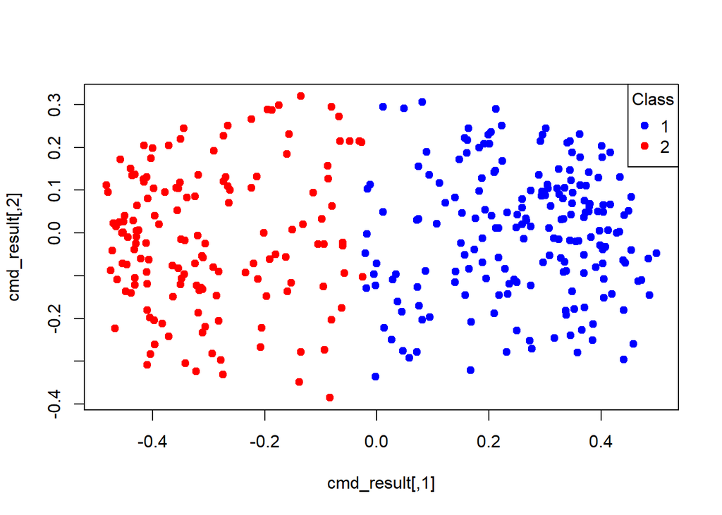

```r
colors <- ifelse(k_means$cluster == 1, 'blue', 'red')

color_factor <- factor(colors, levels = c('blue', 'red'))

plot(cmd_result, col = colors, pch = 19)
legend("topright", legend = c('1','2'), col = levels(color_factor), pch = 19, title = "Class")
```

### Part F

```r
mrun <- Mclust(cmd_result, G=1:6)
t(mrun$BIC)
```

```
## Bayesian Information Criterion (BIC):
##             1        2        3        4        5        6
## EII -138.3982 355.7648 362.9855 386.6359 387.2951 416.4601
## VII -138.3982 349.7271 400.5381 406.6416 433.2811 431.7960
## EEI  128.6049 352.4105 428.4158 452.1234 463.2730 466.0254
## VEI  128.6049 346.3489 451.7854 474.5390 500.4131 489.7436
## EVI  128.6049 347.4166 423.2005 443.1983 452.4908 451.9888
## VVI  128.6049 368.6731 480.7041 474.0827 495.2303 486.2804
## EEE  122.5295 346.8456 432.5525 454.7219 477.4899 472.8307
## VEE  122.5295 340.8421 454.6219 481.8702 498.8761 483.7543
## EVE  122.5295 341.6965 427.5874 439.7113 463.9331 445.2878
## VVE  122.5295 363.8768 478.8831 467.4849 486.8870 479.6194
## EEV  122.5295 340.8374 423.0056 433.0711 451.7624 435.8881
## VEV  122.5295 346.6227 450.5796 469.0756 469.3496 399.7563
## EVV  122.5295 335.7557 417.7866 426.2810 440.8429 440.3431
## VVV  122.5295 360.1159 471.5715 457.3049 480.5732 463.1684
##
## Top 3 models based on the BIC criterion:
##    5,VEI    5,VEE    5,VVI
## 500.4131 498.8761 495.2303
```

```r
conf_matrix <- table(data$Class, mrun$classification)
print(conf_matrix)
```

```
##
##                1   2   3   4   5
##   democrat    26  39 138  63   1
##   republican  45  27   0   4  92
```

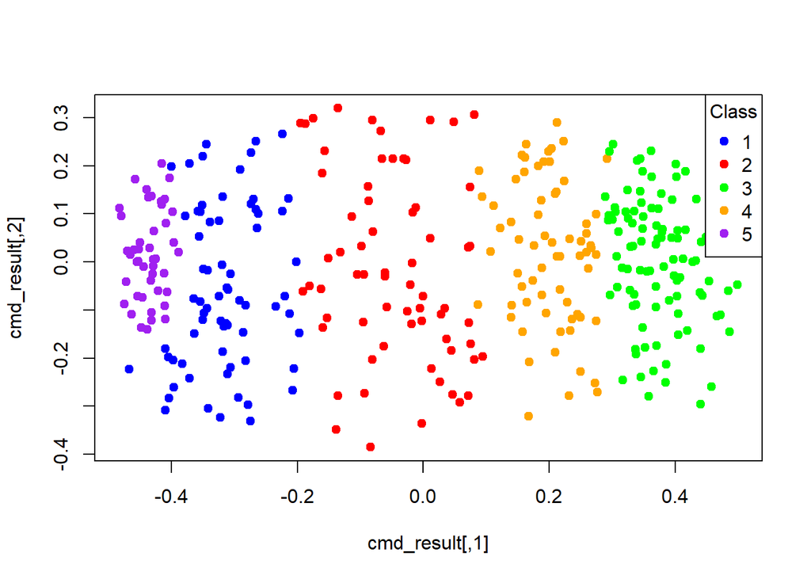

```r
colors <- mrun$classification
colors <- replace(colors, colors==1,"blue")
colors <- replace(colors, colors=="2","red")
colors <- replace(colors, colors=="3","green")
colors <- replace(colors, colors=="4","orange")
colors <- replace(colors, colors=="5","purple")

color_factor <- factor(colors, levels = c('blue', 'red', 'green', 'orange', 'purple'))

plot(cmd_result, col = colors, pch = 19)
legend("topright", legend = c('1','2', '3', '4', '5'), col = levels(color_factor), pch = 19, title = "Class")
```

Based on BIC, 5 groups are suggested.

## Question 2

### Part A

```r
cov_mat <- ability.cov$cov
fa_results <-  factanal(covmat=cov_mat, factors=1, n.obs=112, rotation="none")
print(fa_results)
```

```
##
## Call:
## factanal(factors = 1, covmat = cov_mat, n.obs = 112, rotation = "none")
##
## Uniquenesses:
## general picture  blocks    maze reading   vocab
##   0.535   0.853   0.748   0.910   0.232   0.280
##
## Loadings:
##         Factor1
## general 0.682
## picture 0.384
## blocks  0.502
## maze    0.300
## reading 0.877
## vocab   0.849
##
##                Factor1
## SS loadings      2.443
## Proportion Var   0.407
##
## Test of the hypothesis that 1 factor is sufficient.
## The chi square statistic is 75.18 on 9 degrees of freedom.
## The p-value is 1.46e-12
```

The null hypothesis is number of factors are sufficient and because the p-value is 1.46e-12, which is low enough to reject the null hypothesis, it concludes that 1 factor is not sufficient to describe the data.

### Part B

```r
corr_mat <- cov2cor(cov_mat)
fa_results <-  factanal(covmat=corr_mat, factors=1, n.obs=112, rotation="none")
print(fa_results)
```

```
##
## Call:
## factanal(factors = 1, covmat = corr_mat, n.obs = 112, rotation = "none")
##
## Uniquenesses:
## general picture  blocks    maze reading   vocab
##   0.535   0.853   0.748   0.910   0.232   0.280
##
## Loadings:
##         Factor1
## general 0.682
## picture 0.384
## blocks  0.502
## maze    0.300
## reading 0.877
## vocab   0.849
##
##                Factor1
## SS loadings      2.443
## Proportion Var   0.407
##
## Test of the hypothesis that 1 factor is sufficient.
## The chi square statistic is 75.18 on 9 degrees of freedom.
## The p-value is 1.46e-12
```

### Part C

```r
fa_results <-  factanal(covmat=cov_mat, factors=2, n.obs=112, rotation="none")
print(fa_results)
```

```
##
## Call:
## factanal(factors = 2, covmat = cov_mat, n.obs = 112, rotation = "none")
##
## Uniquenesses:
## general picture  blocks    maze reading   vocab
##   0.455   0.589   0.218   0.769   0.052   0.334
##
## Loadings:
##         Factor1 Factor2
## general  0.648   0.354
## picture  0.347   0.538
## blocks   0.471   0.748
## maze     0.253   0.408
## reading  0.964  -0.135
## vocab    0.815
##
##                Factor1 Factor2
## SS loadings      2.420   1.162
## Proportion Var   0.403   0.194
## Cumulative Var   0.403   0.597
##
## Test of the hypothesis that 2 factors are sufficient.
## The chi square statistic is 6.11 on 4 degrees of freedom.
## The p-value is 0.191
```

The p-value for the 2 factor results is 0.191 which is large enough to NOT reject the null hypothesis, indicating 2 factors is sufficient to describe the data.

Looking at the factor 1 loadings, all are positive, indicating they are correlated and that if an individual does well on 1, they are likely to do well on the others. Factor 1 is mostly correlated with reading and vocab which suggests the latent factor 1 could be literacy strength.

Factor 2 is mostly correlated with the blocks and somewhat picture tests, which could suggest the 2nd latent factor has something to do with creativity.

### Part D

```r
fa_results <-  factanal(covmat=cov_mat, factors=2, n.obs=112, rotation="varimax")
print(fa_results)
```

```
##
## Call:
## factanal(factors = 2, covmat = cov_mat, n.obs = 112, rotation = "varimax")
##
## Uniquenesses:
## general picture  blocks    maze reading   vocab
##   0.455   0.589   0.218   0.769   0.052   0.334
##
## Loadings:
##         Factor1 Factor2
## general 0.499   0.543
## picture 0.156   0.622
## blocks  0.206   0.860
## maze    0.109   0.468
## reading 0.956   0.182
## vocab   0.785   0.225
##
##                Factor1 Factor2
## SS loadings      1.858   1.724
## Proportion Var   0.310   0.287
## Cumulative Var   0.310   0.597
##
## Test of the hypothesis that 2 factors are sufficient.
## The chi square statistic is 6.11 on 4 degrees of freedom.
## The p-value is 0.191
```

The uniqueness, p-value, and cumulative variance for the last factor have not changed.

Factor 1 is mostly correlated with reading and a close second is vocab, which again suggests some latent factor associated with literacy strength.

Factor 2 is mainly correlated with the block design test, which suggests some link to the creativity or imaginative ability of an individual.

Because the varimax rotation forces each variable to load heavily on 1 factor, it helps push variables towards a smaller subset of latent factors vs. apply no rotations - so we can more clearly see which variables correspond more closely to which latent factors.

### Part E

```r
fa_results <-  factanal(covmat=cov_mat, factors=2, n.obs=112, rotation="promax")
print(fa_results)
```

```
##
## Call:
## factanal(factors = 2, covmat = cov_mat, n.obs = 112, rotation = "promax")
##
## Uniquenesses:
## general picture  blocks    maze reading   vocab
##   0.455   0.589   0.218   0.769   0.052   0.334
##
## Loadings:
##         Factor1 Factor2
## general  0.364   0.470
## picture          0.671
## blocks           0.932
## maze             0.508
## reading  1.023
## vocab    0.811
##
##                Factor1 Factor2
## SS loadings      1.853   1.807
## Proportion Var   0.309   0.301
## Cumulative Var   0.309   0.610
##
## Factor Correlations:
##         Factor1 Factor2
## Factor1   1.000   0.557
## Factor2   0.557   1.000
##
## Test of the hypothesis that 2 factors are sufficient.
## The chi square statistic is 6.11 on 4 degrees of freedom.
## The p-value is 0.191
```

A factor correlation matrix has been added to the output because we have applied a non-orthogonal rotation which allows for correlation among the factors unlike previously where this was not allowed. As such, adding this to the output is helpful to address the correlation between factors.

Factor 1, similar to the previous case it is heavily loaded on reading and vocab which again points to some sort of literary proficiency.

Factor 2, again is highly correlated with the block design test which suggests some sort of latent factor that measures an individuals creative ability.

In addition, there is some correlation between the factors which suggests someone with high literary abilities is likely to also have high creativity.

The loadings are about the same to interpret as the varimax rotation but are better when compared to no rotations because each variable is heavily loaded on a factor. Moreover, the additional correlation matrix between the factors is helpful because it shows the factors are not independent, which was not known with the varimax rotation.

## Question 3

### Part A

#### Loading images

```r
read_mnist_labels <- function(filename) {
  fileConn <- file(filename, 'rb')

  magicNumber <- readBin(fileConn, what = 'integer', n = 1, size = 4, endian = "big")
  numberOfItems <- readBin(fileConn, what = 'integer', n = 1, size = 4, endian = "big")

  labels <- readBin(fileConn, what = 'integer', n = numberOfItems, size = 1)

  close(fileConn)

  return(labels)
}

read_mnist_images <- function(filename) {
  fileConn <- file(filename, 'rb')

  magicNumber <- readBin(fileConn, what = 'integer', n = 1, size = 4, endian = "big")
  numberOfImages <- readBin(fileConn, what = 'integer', n = 1, size = 4, endian = "big")
  numberOfRows <- readBin(fileConn, what = 'integer', n = 1, size = 4, endian = "big")
  numberOfColumns <- readBin(fileConn, what = 'integer', n = 1, size = 4, endian = "big")

  image_data <- readBin(fileConn, what = 'integer', n = numberOfImages * numberOfRows * numberOfColumns, size = 1)

  image_data <- array(image_data, dim = c(numberOfRows, numberOfColumns, numberOfImages))

  close(fileConn)

  return(image_data)
}

flip_image_horizontally <- function(img) {
  apply(img, 1, rev)
}

labels <- read_mnist_labels("fashion_data/t10k-labels-idx1-ubyte")
images <- read_mnist_images("fashion_data/t10k-images-idx3-ubyte")

flipped_images <- lapply(1:dim(images)[3], function(i) flip_image_horizontally(images[,,i]))

flipped_images_array <- array(unlist(flipped_images), dim = c(dim(images)[1], dim(images)[2], dim(images)[3]))

images <- flipped_images_array
```

```r
load_mnist <- function() {
  load_image_file <- function(filename) {
    ret = list()
    f = file(filename,'rb')
    readBin(f,'integer',n=1,size=4,endian='big')
    ret$n = readBin(f,'integer',n=1,size=4,endian='big')
    nrow = readBin(f,'integer',n=1,size=4,endian='big')
    ncol = readBin(f,'integer',n=1,size=4,endian='big')
    x = readBin(f,'integer',n=ret$n*nrow*ncol,size=1,signed=F)
    ret$x = matrix(x, ncol=nrow*ncol, byrow=T)
    close(f)
    ret
  }
  load_label_file <- function(filename) {
    f = file(filename,'rb')
    readBin(f,'integer',n=1,size=4,endian='big')
    n = readBin(f,'integer',n=1,size=4,endian='big')
    y = readBin(f,'integer',n=n,size=1,signed=F)
    close(f)
    y
  }
  test <<- load_image_file('fashion_data/t10k-images-idx3-ubyte')
  test$y <<- load_label_file('fashion_data/t10k-labels-idx1-ubyte')
}

load_mnist()
images <- as.matrix(test$x)
labels <- test$y

images_reshaped <- array(0, dim = c(nrow(images), 28, 28))
for (i in 1:nrow(images)) {
  images_reshaped[i,,] <- matrix(images[i,], nrow = 28, byrow = TRUE)
}

# Fix orientation of images
fixed_images <- array(0, dim = dim(images_reshaped))
for (i in 1:nrow(images_reshaped)) {
  fixed_images[i,,] <- t(apply(images_reshaped[i,,], 2, rev))
}
images_permuted <- aperm(fixed_images, c(2, 3, 1))

images <- images_permuted
```

#### Plotting first 25 images

[figure not shown]

```r
par(mfrow=c(5,5), omi=c(0,0,0,0), mai=c(0.1,0.1,0.1,0.1))
for (i in 1:25){
  image(images[,,i], col=gray(12:1/12))
}
```

### Part B

```r
images_1d <- apply(images, 3, as.vector)
images_1d <- t(images_1d)
image_pca <- prcomp(images_1d)
save(image_pca, file = "image_pca.Rdata")
```

Maximum number of components that are permittable is 784 components because images are 28x28 = 784.

### Part C

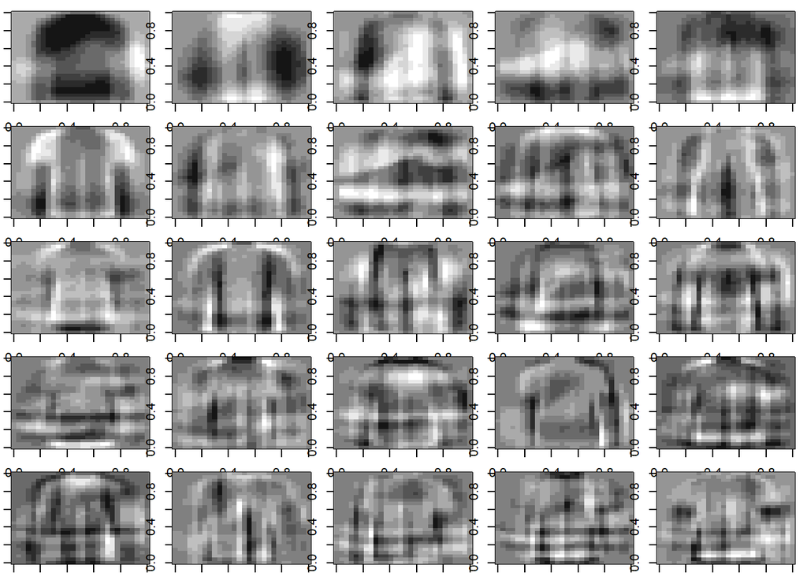

```r
images_1d <- apply(images, 3, as.vector)
images_1d <- t(images_1d)
load("image_pca.Rdata")

par(mfrow=c(5,5), omi=c(0,0,0,0), mai=c(0.1,0.1,0.1,0.1))
for(i in 1:25){
  image(matrix(image_pca$rotation[,i], 28, 28), col=gray(12:1/12))
}
```

About 80% of the original variation in pixels is explained by the first 25 components.

### Part D

[figure not shown]

```r
par(mfrow=c(5,4), omi=c(0,0,0,0), mai=c(0.1,0.1,0.1,0.1))
for (i in 1:10){
  p_comp <- 25
  reconst <- (image_pca$rotation[,1:p_comp] %*% t(image_pca$x[,1:p_comp]))
  image(matrix(reconst[,i], 28, 28), col=gray(12:1/12), xaxt="n", yaxt="n")
  image(images[,,i], col=gray(12:1/12))
}
```

### Part E

```r
nmf <- function(x, q, eps=0.001, maxit=2000, w=NULL, h=NULL){
  n <- nrow(x)
  p <- ncol(x)
  if(any(x<0)){x <- as.matrix(x)+abs(min(x))}
  else{x <- as.matrix(x)}
  if(is.null(w)){
    w <- matrix(runif(n*q, min(x), max(x)), n, q)
  }
  if(is.null(h)){
    h <- matrix(runif(p*q, min(x), max(x)), q, p)
  }
  ed <- sum((x-w%*%h)^2)
  conv <- FALSE
  ctr <- 1
  while(!conv){
    ctr <- ctr+1
    h <- h * (t(w) %*% x) / (t(w) %*% w %*% h)
    w <- w * (x %*% t(h)) / (w %*% h %*% t(h))
    wh <- w%*%h
    ed[ctr] <- sum((x-wh)^2)
    if((ed[ctr-1]-ed[ctr] < eps)|(ctr==maxit)){
      conv <- TRUE
    }
  }
  list(ed=ed, w=w, h=h, x=x)
}

set.seed(5213541)
test <- nmf(images_1d, 25, maxit=600)
save(test, file = "nmf_results.Rdata")
```

#### Continued

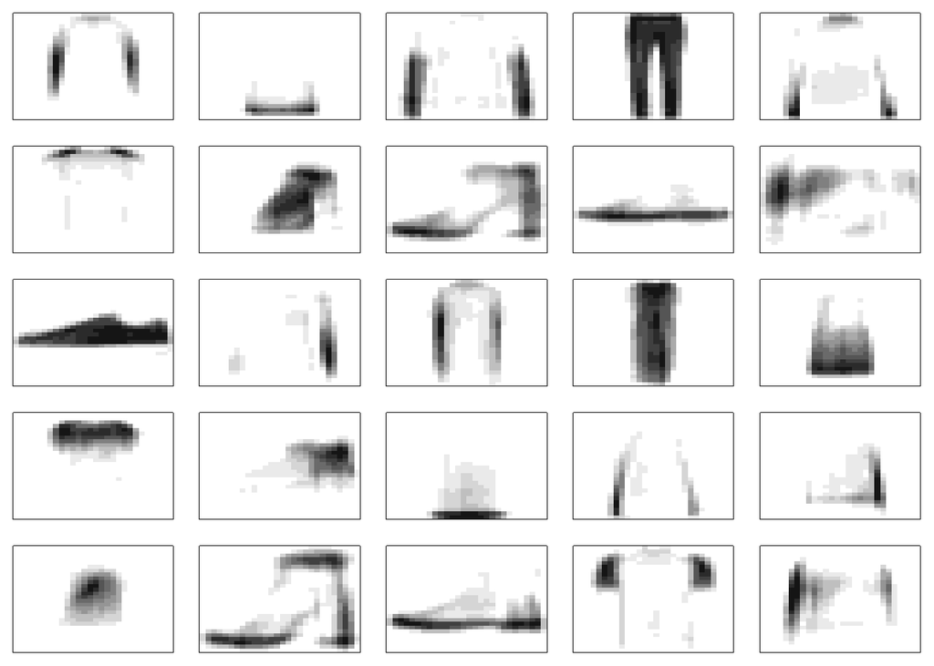

```r
load("nmf_results.Rdata")

par(mfrow=c(5,5), omi=c(0,0,0,0), mai=c(0.1,0.1,0.1,0.1))
for(i in 1:25){
  image(matrix(test$h[i,], 28, 28), col=gray(12:1/12), xaxt="n", yaxt="n")
}
```

Looking at the first 25 basis vector images, I can see some are very clear (mostly the shoes) and some are blurry. They all have some dark areas which they are regions of importance for that basis. The biggest difference being it doesn’t look like a t-shirt or clothing article is imposed on the image unlike in PCA.

In contrast, for the principal components, many of the images look very similar. The background in these images is mostly neutral ie. gray, likely due to the averaging. Most importantly, for many of the components, it looks like there are many images on top of each other making the overall image unclear.

Due to the additivity requirement from NMF, components can only be added, whereas in PCA they can be added and subtracted. As such, the interpretations gotten from the NMF bases are more interesting than that from the principal components.

### Part F

[figure not shown]

```r
nmfrec <- test$w %*% test$h

par(mfrow=c(5,4), omi=c(0,0,0,0), mai=c(0.1,0.1,0.1,0.1))
for (i in 1:10){
  image(matrix(nmfrec[i,], 28, 28), col=gray(12:1/12), xaxt="n", yaxt="n")
  image(images[,,i], col=gray(12:1/12))
}
```

### Part G

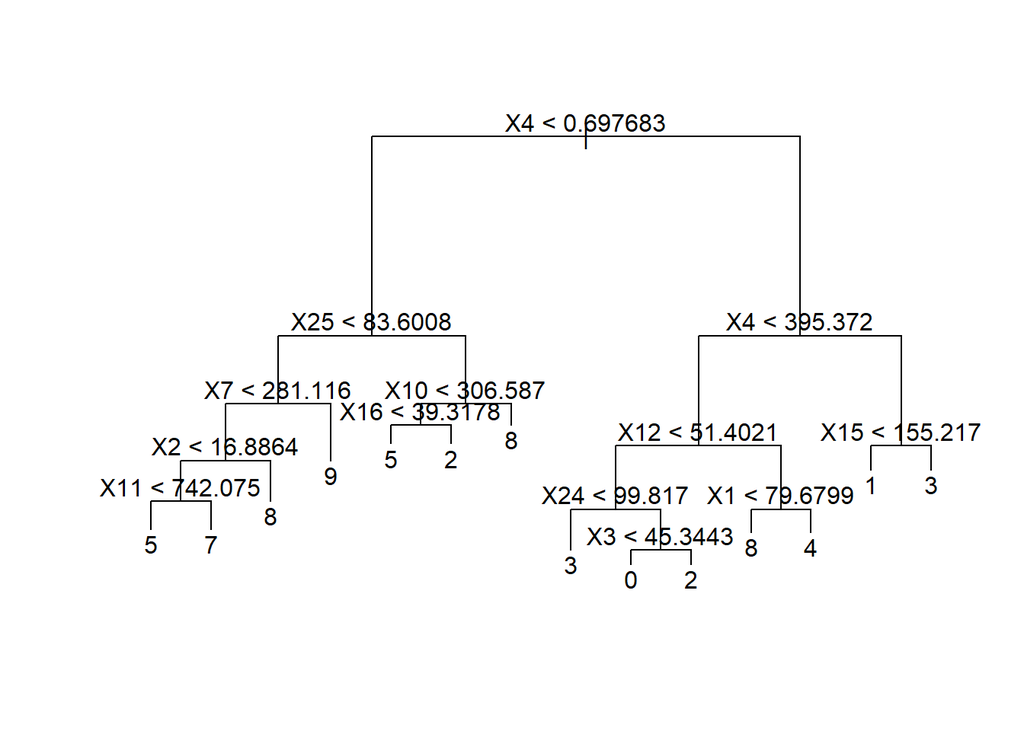

```r
scores <- test$w
data <- data.frame(scores, as.factor(labels))
names(data)[names(data) == "as.factor.labels."] <- "labels"

tree_model <- tree(labels ~ ., data = data)
plot(tree_model)
text(tree_model)
```

### Part H

```r
set.seed(123)

cv_out <- cv.tree(tree_model, FUN=prune.misclass)

optsize <- cv_out$size[which.min(cv_out$dev)]
print(optsize)
```

```
## [1] 14
```

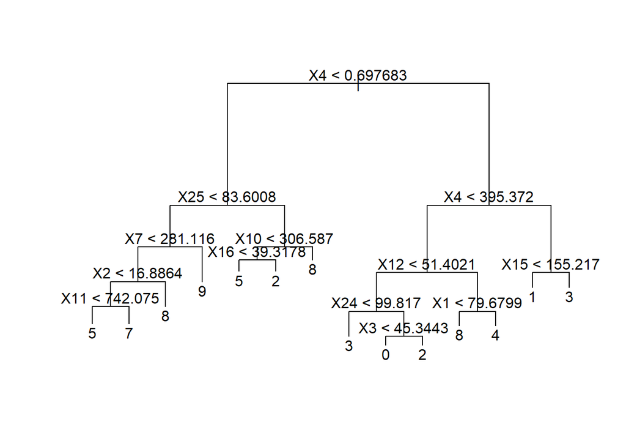

```r
pruned_tree <- prune.misclass(tree_model, best=optsize)
plot(pruned_tree)
text(pruned_tree)
```

```r
misclassification_rate_best_tree <- cv_out$dev[which.min(cv_out$dev)] / 10000
print(misclassification_rate_best_tree)
```

```
## [1] 0.3881
```

Comparing the pruned tree to the original, they are both the same size, hence, 0 nodes are suggested to be removed for the best tree with lowest deviance.

The missclassification rate for the best tree is about 39%.